# Assignment1

Shone George Kutty Renjan

2024-09-06

[output not shown]

# Questions

## Question 1

```r
Course_grading <- data.frame(
  Course_Elements = c("Assignments", "Laboratories", "Projects", "In-Class Quizzes", "Quizzes (Online)", "Mid-Term Exams", "Final Exam"),
  Count = c("4", "16", "2", "TDH", "TDH", "2", "1"),
  Weight_Each = c("3.75%", "0.625%", "3.33% & 6.67%", "-", "-", "10%", "30%"),
  Total_Weight = c("15%", "10%", "10%", "10%", "5%", "20%", "30%")
)

print("COURSE DESCRIPTION")
```

```
## [1] "COURSE DESCRIPTION"
```

```r
print(Course_grading)
```

```
##    Course_Elements Count   Weight_Each Total_Weight
## 1      Assignments     4         3.75%          15%
## 2     Laboratories    16        0.625%          10%
## 3         Projects     2 3.33% & 6.67%          10%
## 4 In-Class Quizzes   TDH             -          10%
## 5 Quizzes (Online)   TDH             -           5%
## 6   Mid-Term Exams     2           10%          20%
## 7       Final Exam     1           30%          30%
```

Total = 100% There is no curve in this course.

```r
grading_scale <- data.frame(
  Grade = c("A", "B", "C", "D", "F"),
  Percentage = c("90% - above", "80% - 89%", "60% - 79%", "50% - 59%", "Below - 50%")
)
grading_scale
```

```
##   Grade  Percentage
## 1     A 90% - above
## 2     B   80% - 89%
## 3     C   60% - 79%
## 4     D   50% - 59%
## 5     F Below - 50%
```

## Question 2

1. Make the coplot as the biologist required Hint: Use coplot(), Lab 1, the code provided, and plotting options pch and col to differentiate the MILE variable.

```r
ddt <- read.csv("DDT-1.csv")
m=with(ddt, as.numeric(factor(MILE))) # A

length(unique(m)) #B
```

```
## [1] 17
```

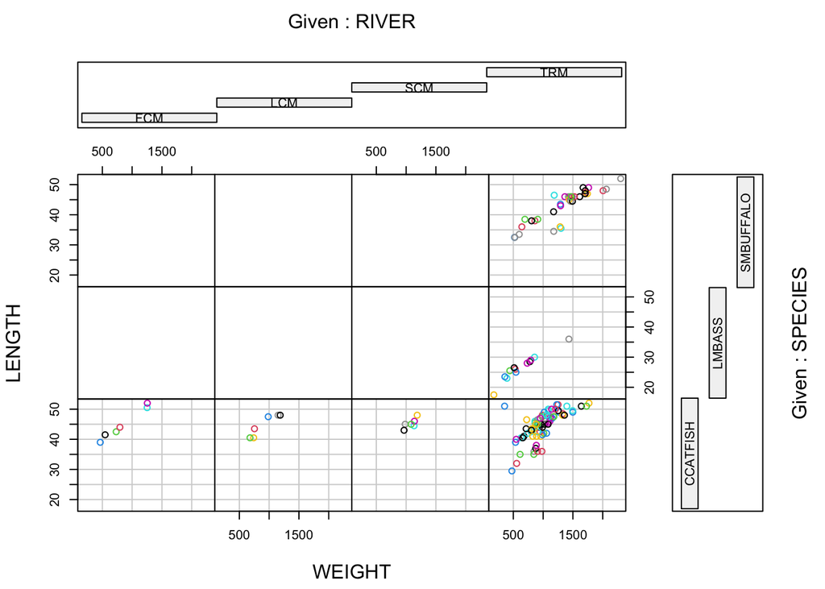

```r
coplot(LENGTH ~ WEIGHT | RIVER * SPECIES, data = ddt, col = unique(m))
```

2. Interpret the lower left three conditional plots.

It shows a positive correlation between the length and weight among the CCATFISH species in all four rivers (FCM, LCM, SCM, TRM)

3. What does line A do?

Line A creates a numeric vector ‘m’ from the ‘MILE’ column in the ‘ddt’ data frame. It first converts ‘MILE’ to a factor and then to numeric values

4. What does line B do?

Calculates the number of unique values in ‘m’ which is MILE

5. Why are the top six plots empty?

6. What is the mean value of DDT found in the sample of CCATFISH caught in the FCM river?

```r
CCATFISH= ddt$DDT[ddt$SPECIES== "CCATFISH" & ddt$RIVER== "FCM"]
mean(CCATFISH)
```

```
## [1] 45
```

## Question 3

### MS1.14

1. Length of the maximum span (feet): quantitative
2. Number of vehicle in lane: quantitative
3. Toll bridge (yes or no): qualitative
4. Average daily traffic: quantitative
5. Condition of the deck (goof, fair, or poor): qualitative
6. Bypass or detour length (miles): quantitative
7. Route type(interstate, U.S., state, country, or city): qualitative

## Question 4

### MS

1. What are the names of the four random sampling designs

The four random sampling designs are simple random sampling, stratified random sampling, Cluster Sampling, and Systematic Sampling.

2. Give a brief description of each.

Simple Random Sampling: This method involves selecting a sample of size n from the population in such a way that every possible sample of size n has an equal chance of being selected.

Stratified Random Sampling: This method is used when the population can be divided into two or more distinct groups, or strata. A random sample is then taken from each group.

Systematic Sampling: This method involves selecting every k-th experimental unit from a list of all units in the population, starting from a randomly chosen point.

Cluster Sampling: In this method, the population is divided into natural groups, or clusters. Then, entire clusters are randomly selected, and data is collected from all units within these selected clusters.

## Question 5

### MS 1.15

Reads the MTBE File

```r
mtbe=read.csv("MTBE.csv", header=TRUE) # You will need to change the address
head(mtbe) # First six lines
```

```
##     pH SpConduct DissOxy RoadsPct IndPct UrbanPct DevPct WellClass Aquifier
## 1 7.87     290.0    0.58     1.34      0    17.77  17.77   Private  Bedrock
## 2 8.63     225.9    0.84     0.72      0    10.43  10.43   Private  Bedrock
## 3 7.11     157.4    8.37     1.92      0    29.62  50.01   Private  Bedrock
## 4 7.98     723.6    0.41     2.76      0    41.65  41.65   Private  Bedrock
## 5 7.88     148.7    1.44     3.51      0    51.21  51.21   Private  Bedrock
## 6 8.36     198.2    0.18     1.48      0    22.49  29.19   Private  Bedrock
##     Depth SafeYld Distance MTBE.Detect MTBE.Level HouseDen PopDen
## 1  60.960      NA  2386.29 Below Limit        0.2   131.16  43.19
## 2  36.576      NA  3667.69 Below Limit        0.2    47.69  24.52
## 3 152.400      NA  2324.15 Below Limit        0.2    85.16  33.32
## 4      NA      NA   788.88 Below Limit        0.2   134.77  46.61
## 5  91.440      NA  1337.88 Below Limit        0.2   198.54  78.58
## 6 115.824      NA  2396.74 Below Limit        0.2   206.73  59.47
```

```r
dim(mtbe) # rows and columns
```

```
## [1] 223  16
```

```r
ind=sample(1:223,5,replace=FALSE) # random indices
mtbe[ind,]
```

```
##       pH SpConduct DissOxy RoadsPct IndPct UrbanPct DevPct WellClass Aquifier
## 143 6.12     395.1    3.22     4.39   0.00    61.97  66.88    Public  Bedrock
## 174 7.81     189.5    8.26     0.71   0.00     8.24  19.35    Public  Bedrock
## 196 7.45    1192.0    0.17     4.33  21.36    35.89  51.75    Public  Bedrock
## 177 7.59     390.4    2.25     4.23  17.46    41.13  53.45    Public  Bedrock
## 92  8.22     175.9    1.32     0.48   0.00     5.59   5.59   Private  Bedrock
##        Depth   SafeYld Distance MTBE.Detect MTBE.Level HouseDen PopDen
## 143 182.8800 113.55034  2193.56      Detect       2.97   336.82 129.05
## 174  79.2480  37.85011  1842.73 Below Limit       0.20    18.76   7.25
## 196 152.4000  18.92506   142.26      Detect      32.80    74.74  26.03
## 177 112.7760  37.85011   782.47      Detect       2.70   134.04  57.45
## 92  128.9304        NA  2762.89 Below Limit       0.20    20.12   7.04
```

```r
mtbe=na.omit(mtbe)
depth=mtbe[mtbe$Aquifier=="Bedrock",]$Depth
sd(depth)
```

```
## [1] 56.45357
```

## Question 6

```r
# random sample
earthquake = read.csv("EARTHQUAKE.csv")
earthquake[sample(1:nrow(earthquake), 30, replace=FALSE),]
```

```
##      YEAR MONTH DAY HOUR MINUTE MAGNITUDE
## 705  1994     1  20   13     47       2.2
## 1447 1994     1  24    3     42       3.0
## 686  1994     1  20   11     38       2.2
## 217  1994     1  18    3      5       2.5
## 220  1994     1  18    3     21       2.7
## 2194 1994     1  29    1     37       1.6
## 2531 1994     2   2   15     10       1.5
## 2706 1994     2   4    3     14       1.4
## 523  1994     1  19   20     15       1.7
## 2056 1994     1  27   23     41       1.6
## 1491 1994     1  24    9     52       2.1
## 2442 1994     2   1   14     28       1.8
## 2726 1994     2   4    7     17       1.8
## 2504 1994     2   2    6     48       1.3
```

[output cut: 16 more lines]

1. Make the following plot plot

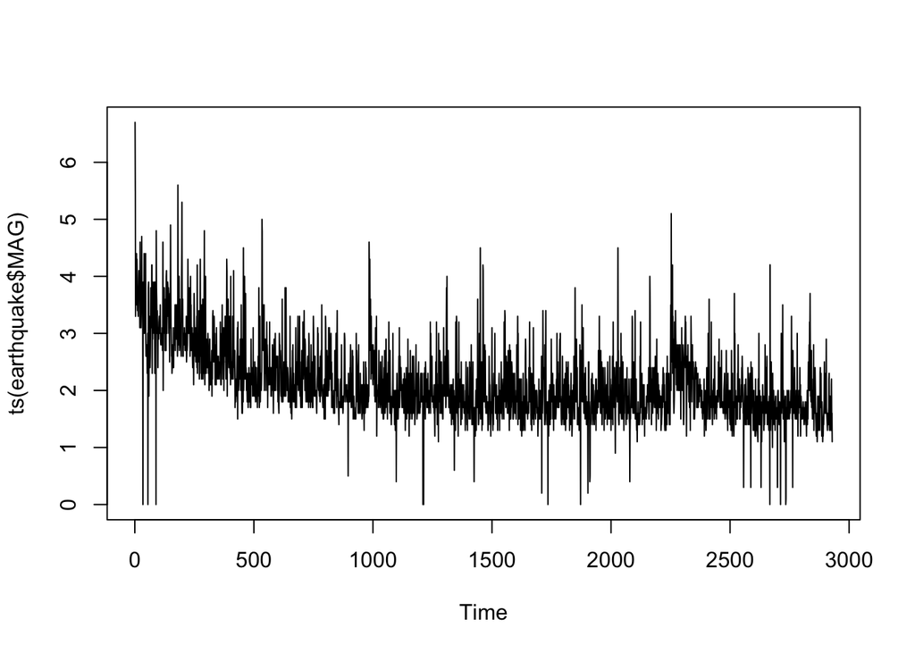

```r
plot(ts(earthquake$MAG))
```

2. Using earthquake data frame find the median

```r
median(earthquake$MAGNITUDE)
```

```
## [1] 2
```

## Question 7

1. What is the data collection method? The data was collection method was stratified sampling
2. What is the population? Population fish in the Tennessee river.
3. Give the names of all the qualitative variables

Qualitative variables: River and Species

## Question 8

1. What type of graph is used to describe this data

Bargraph

2. Identify the variable measured for each of the 106 robotic design

Robotic Limbs

3. Use graph to identify the robot design currently most used

Legs

4. Compute the relative frequencies for the most categories shown in the graph

```r
freq = c(15, 8, 63, 20)
fsum = sum(freq)
relfreq = freq / fsum
relativefrequencies <- data.frame(
  RL = c("None", "Both", "LegsO", "WheelsO"),
  relfreq
)
relativefrequencies
```

```
##        RL   relfreq
## 1    None 0.1415094
## 2    Both 0.0754717
## 3   LegsO 0.5943396
## 4 WheelsO 0.1886792
```

5. pareto diagram

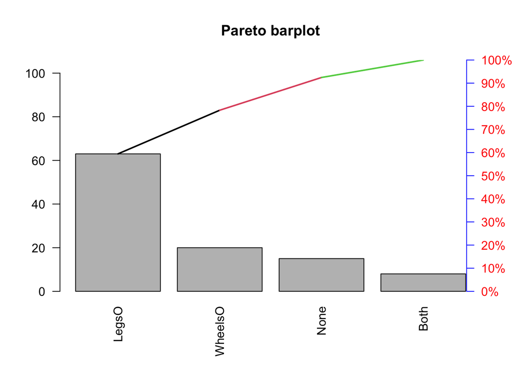

```r
pareto <- function(x, mn = "Pareto barplot", ...) {  # x is a vector
  x.tab = table(x)
  xx.tab = sort(x.tab, decreasing = TRUE, index.return = FALSE)
  cumsum(as.vector(xx.tab)) -> cs
  length(x.tab) -> lenx
  bp <- barplot(xx.tab, ylim = c(0,max(cs)),las = 2)
  lb <- seq(0,cs[lenx], l = 11)
  axis(side = 4, at = lb, labels = paste(seq(0, 100, length = 11), "%", sep = ""), las = 1, line = -1, col = "Blue", col.axis = "Red")
  for(i in 1:(lenx-1)){
    segments(bp[i], cs[i], bp[i+1], cs[i+1], col = i, lwd = 2)
  }
  title(main = mn, ...)
}
RL = c("None", "Both", "LegsO", "WheelsO")
l=rep(RL,freq)
pareto(l)
```

## Question 15

BOXPLOT

[output not shown]